# Check how to Schreck

Semester Project of the module PTED FS 22

Fabienne Gräppi and Benjamin Bar-Gera

# Abstract

As part of a previous study, a number of wild boar scare off elements have been employed throughout the Fanel region at the western end of Lake Neuchâtel. The point of these acoustic elements is to scare off the animals so that they disperse and create less damage to the agricultural crops around the scare off elements. As a result of this previous study, we have access to a data set which includes the type and agenda for the scare off elements, as well as the GPS points for a number of wild boars that were living in this area throughout the period when the scare off elements were employed. Using exploratory and confirmatory data analysis methods, we tried to discern whether these scare off elements have any effect on the spatial distribution of the animals, and if so, what settings are the most effective at dispersing the animals. However, based on our analysis the effect of the scare off elements was insignificant at scarring away the animals, and sometimes even seemed to have an attractive effect on them. Based on this, modeling the response of the wild boars as a function of the settings was not possible due to the low statistical power. However, a visual comparison of five relevant scare off parameter settings showed that mode and volume could be important factors. Nevertheless, further confirmatory investigations are necessary to confirm these results. All in all, this exercise allowed us to employ the various concepts and tools which we learned throughout the module Patterns and Trends in Environmental Data.

# Introduction

Since almost going extinct in some parts of Europe the population of wild boars (*Sus scrofa*) has increased strongly <sup>1,2</sup>, and they are now the fifth largest ungulate species in Europe <sup>3,4</sup>. The increase of population in Europe has had significant influence on the biodiversity in forests and an economic impact on cultivated areas due to damage in crop fields and transmission of diseases on domestic animals <sup>3</sup>. In Switzerland the damages from wild boars to cultivated areas cumulate to several million CHF a year <sup>5</sup>. In order to reduce damage from wild boars in Switzerland, the Federal Environmental Agency (Bundesamt für Umwelt/BAFU) has released a document with tips and guidelines for the regulation of wild boar management and damage prevention. Measures described in the guideline include population control through hunting, employment of damage reducing actions, such as the use of electrical fences around cultivated areas or dissuasive feeding and the appropriate reimbursement for damages <sup>2,6,7</sup>. Hunting to reduce population might be the most effective way to reduce damages but it can also have a negative impact on the living environment of other animals or plants and is highly time- as well as work-intensive <sup>4,6,7</sup>. Other measures such as electrical fencing are also time-intensive and costly to install. However, adequate defense measures are needed in the future as with population growth and the increasing distribution of wild boars, the pressure on agricultural land will continue to increase. Due to the drawbacks of the described measures cheaper and less time- and work-consuming instruments have been tested such as acoustic scare offs (also known as ‘schrecks’) <sup>1</sup>. Wild boars have a keen sense of hearing and communicate with each other with warning sounds when they sense danger <sup>8</sup>. This characteristic can be exploited to keep wild boars away from agricultural land by means of an acoustic scare device. This involves playing wild boar warning sounds or other sounds that signify danger at intervals.

Previous studies at the Department WILMA (Wildtiermanagement) at the ZHAW have demonstrated a reduction in damage to agricultural crops. In addition, the effectiveness of acoustic wild boar scare offs should now be analyzed with this study, in terms of their influence on the spatial behavior of wild boars.

# Aim of the Study and Research Questions

This present study is developed within the module Patterns and Trends in Environmental Data (PTED 22). The effectiveness of the acoustic wild boar scare off systems is to be investigated on the basis of the spatial behavior of wild boars. In the course of this, GPS location data of wild boars with different sampling intervals over a period of about 2 years and data sets of scare off locations and agenda were provided. The area of interest in this study is the Fanel region at the western end of Lake Neuchâtel.

The aims of this study are to answer the following research questions:

- Q1: How effective are the Wildschwein-Schreck (WS) at keeping away wild boar and how long do these effects last?
- Q2: What settings (mode, noise level, interval, azimuth) and setting-combintations are most effective at keeping away wild boar?

# Material and Methods

## Data and Packages

Following R-Packages were used for the data processing and analysis:

- ComputationalMovementAnalysisData
- tidyverse
- sf
- leaflet
- leaflet.extras2
- gganimate
- ggspatial
- cowplot
- knitr
- multcompView
- pander

Table 1: Wild boar location data

| TierID | TierName | CollarID | DatetimeUTC | E | N | day | moonilumination |
| --- | --- | --- | --- | --- | --- | --- | --- |
| 1 | Ueli | 12272 | 2014-05-28 21:01:14 | 2570390 | 1204820 | Tag | 0.0033556 |
| 1 | Ueli | 12272 | 2014-05-28 21:15:18 | 2570389 | 1204826 | Abenddaemmerung | 0.0033556 |
| 1 | Ueli | 12272 | 2014-05-28 21:30:13 | 2570391 | 1204821 | Abenddaemmerung | 0.0033556 |
| 1 | Ueli | 12272 | 2014-05-28 21:45:11 | 2570388 | 1204826 | Abenddaemmerung | 0.0033556 |
| 1 | Ueli | 12272 | 2014-05-28 22:00:33 | 2570388 | 1204819 | 1Nachtviertel | 0.0033556 |
| 1 | Ueli | 12272 | 2014-05-28 22:15:16 | 2570384 | 1204828 | 1Nachtviertel | 0.0033556 |

Table 2: Scare off location data

| id | region | flurname | kultur | installationshohe | zaun | jagddruck | lat | lon |
| --- | --- | --- | --- | --- | --- | --- | --- | --- |
| WSS_2014_01 | elfingen | rüti | weizen&hafer | 1.80 | nein | mittel | 47.51406 | 8.095919 |
| WSS_2014_02 | elfingen | steiacher | weizen | 1.95 | nein | mittel | 47.49951 | 8.122986 |
| WSS_2014_03 | elfingen | schlotterbode | weizen&sorgungras | 1.80 | nein | mittel | 47.50564 | 8.110089 |
| WSS_2014_04 | fanel | tannenhof | kartoffeln&mais | 1.80 | ja | gering | 46.99720 | 7.056506 |
| WSS_2014_05 | fanel | tannenhof | karotten&kartoffeln | 1.80 | nein | gering | 46.99433 | 7.058764 |
| WSS_2014_06 | fanel | fanelacher | kartoffeln&mais&zuckerrueben | 1.80 | nein | gering | 47.01424 | 7.039208 |

Table 3: Scare off on/off, interval and parameter data

| id | datum_on | datum_off | modus | lautstaerke | intervall | ausrichtung_min | ausrichtung_max | phase |
| --- | --- | --- | --- | --- | --- | --- | --- | --- |
| WSS_2014_01 | 2014-04-01 | 2014-06-20 | standard v1 | 100 | 15 | 80 | 280 | 2 |
| WSS_2014_01 | 2014-07-23 | 2014-09-19 | standard v1 | 100 | 15 | 80 | 280 | 2 |
| WSS_2014_02 | 2014-04-26 | 2014-08-08 | standard v1 | 50 | 4 | 45 | 225 | 2 |
| WSS_2014_03 | 2014-04-26 | 2014-08-08 | standard v1 | 100 | 15 | 30 | 180 | 2 |
| WSS_2014_03 | 2014-09-19 | 2014-10-18 | standard v1 | 50 | 20 | 30 | 180 | 2 |
| WSS_2014_04 | 2014-05-01 | 2014-10-28 | standard v1 | 33 | 15 | 200 | 280 | 2 |

## Data Preprocessing and Tools

Both the wildboar and the scare off data was filtered. The data was filtered for the relevant areas and time periods. As a first step, only wild boar location data within the closer proximity of the scare off locations was considered. Therefore, the data frames were transformed to sf objects and visually investigated (*Figure 1*) as well as cropped to the relevant area (*Figure 2*).

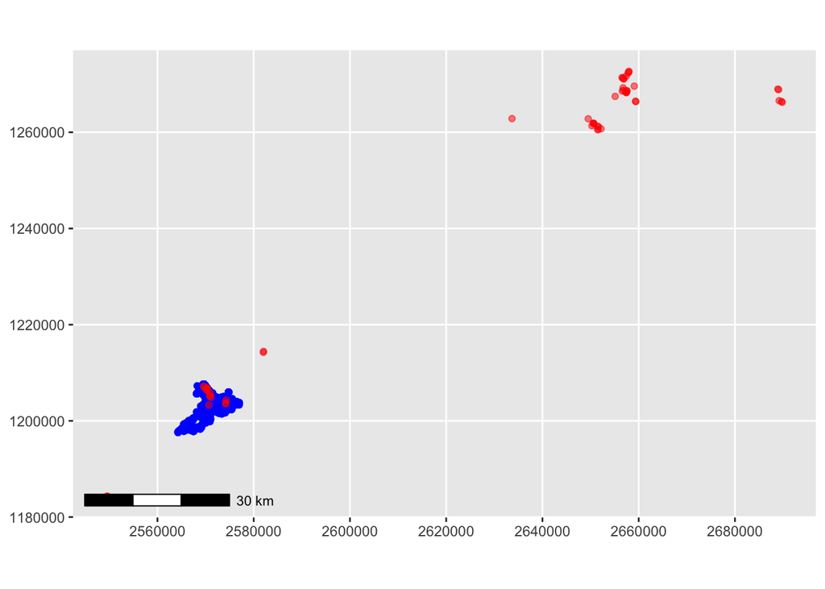

Figure 1: Wild boar locations (blue) and scare off locations (red) uncropped

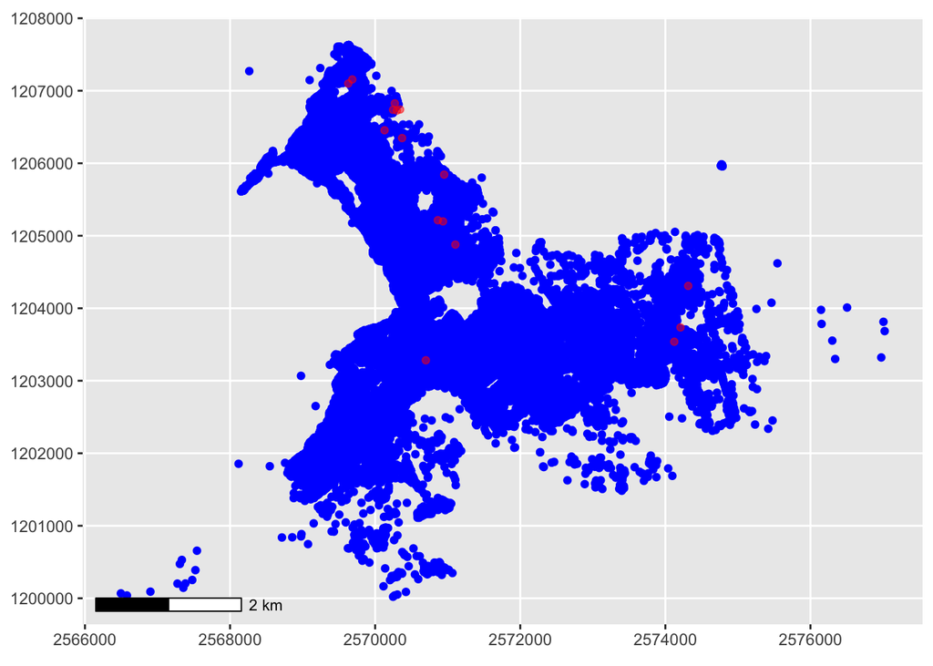

Figure 2: Wild boar locations (blue) and scare off locations (red) cropped

Secondly, the two data frames for the scare off locations and the scare off agenda were merged to a single data frame and afterwards filtered according to the time when wild boar data was available. After filtering, 7 relevant scare off events and locations remained (*Table 4*).

Table 4: Scare offs active within wild boar sampling period

| id | datum_on | datum_off | geometry |
| --- | --- | --- | --- |
| WSS_2015_01 | 2015-05-20 | 2015-07-01 | POINT (2570864 1205214) |
| WSS_2015_03 | 2015-05-22 | 2015-07-01 | POINT (2569685 1207155) |
| WSS_2015_04 | 2015-05-27 | 2015-07-01 | POINT (2570247 1206737) |
| WSS_2016_01 | 2016-04-04 | 2016-04-23 | POINT (2570699 1203282) |
| WSS_2016_05 | 2016-06-15 | 2016-07-15 | POINT (2574315 1204308) |
| WSS_2016_06 | 2016-06-15 | 2016-07-15 | POINT (2570344 1206741) |
| WSS_2016_13 | 2016-09-29 | 2016-10-04 | POINT (2570951 1205843) |

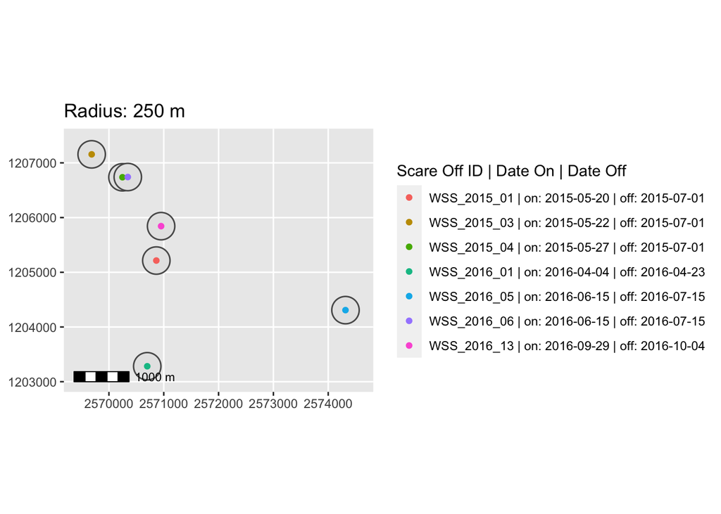

Figure 3: Scare off location overlap

Additionally, for the statistical approaches we had to neglect two scare offs. WSS_2016_06 provides only 11 GPS points within a scare off duration of 30 days (with 10 days before and 14 days after the scare off event and a buffer zone with a radius of 500 m around the scare off location) and WSS_2016_13 was active only for 5 days which is not comparable to the other scare off events.

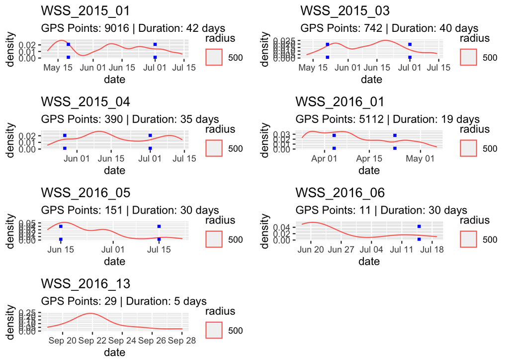

Figure 4: Density plots of scare offs active during wild boar location sampling with duration and number of GPS point

## Functions

### Density Plots Function

To get an impression if the scare offs influences the occurrence of wild boars and how far their effect ranges, we designed a function. The function `draw_density_plot(schreck_id, radii, days_before, days_after)` is used to filter the data by observation radius and time for one scare off to then plot it as a density function. Thereby, the time period of days before and after the event can be set, while the time period during the event is provided by the scare off agenda.

### Interactive Map Function

To visually explore how an active scare off affects the spatial distribution of wild boars, we wrote a function `generate_interactive_map(schreck_id, radius, days_before, days_after)`. The function takes as parameters a specific scare off, the radius of the buffer zone, as well as the number of days before and after the scare off event which should also be included. The function generates an interactive leaflet map which allows the user to swipe through time (from before until after the scare off event) and see the GPS points of the wild boars which occurred within the predefined buffer zone throughout this time period.

### Static Map (All Individuals) Function

As an alternative to the interactive map function, we also wrote a function called `generate_static_maps(schreck_id, radius, days_before, days_after)`. The function takes a specific scare off, a predefined buffer zone radius, and the number of days before and after the scare off event are over to be included. The function generates three maps, each one showing all data points within a period in relation to the scare off event (before, during, and after the scare off). Only data points that fall within this time period (days before scare off event until days after scare off event) and within the buffer zone are considered. The maps also differentiate between the individuals by providing them with different colors.

### Static Map (One Individual) Function

In addition to the interactive map function, we wrote a function called `generate_static_map_individual_wild_boar(schreck_id, radius, days_before, days_after, tier_id)`. The function takes a specific scare off, a predefined buffer zone radius, the number of days before and after the scare off event are over to be included, as well as the ID of a specific individual wild boar. The function generates one map which shows all of that individual’s GPS points during this time period (days before scare off event until days after scare off event), even outside of the defined buffer zone. The map also shows the buffer zone (orange circle), the scare off location and uses color to differentiate between the GPS points which happened before, during, and after the scare off event.

To decide which individual to focus on we wrote the function `generate_data_points_table(schreck_id, radius, days_before, days_after)`, which shows us for a specific scare off location and event, which individual has the most GPS points within that time period and buffer zone.

### ANOVA/Boxplot Function

In order to statistically and visually confirm whether a scare off event has an effect on the distribution of wild boars in its vicinity, we wrote the function `anova_for_schreck(schreck_id, radius)`. The function takes as input parameters a specific scare off and a radius for its buffer zone. The function then generates an ANOVA for the number of GPS points **per day** within that buffer zone for the period before, during, and after the scare off event. The function then runs a post-hoc tukey test to and applies the labels from this test to a boxplot, allowing the user to easily see whether significant (p < 0.05) differences between these groups (before, during, after) exist.

# Results

## Effect of Scare Off on Total Wild Boar Occurance (Q1)

### Exploratory Analysis

#### Density Plots

The wild boar density shows different patterns for each scare off event (*Figure 5*). The number of GPS points for each event ranges from 178 (WSS_2016_05) to over 10’000 points (WSS_2015_01). For WSS_2015_01, WSS_2015_03, and WSS_2015_04 we observe the contrary pattern of what we expected, the occurrence increases during the first half of the event and then begins to decrease. The occurrence change is very similar when considering 100 m, 200 m or 400 m radius. However, the amplitude decreases with larger radii. WSS_2016_01 and WSS_2016_05 follow more the expected pattern, but the difference of the number of GPS points is high. For those scare off we observe higher amplitudes for smaller radii. While for WSS_2016_05 the size of the radius has a low impact on the observations, it has a great impact for WSS_2016_01 observations.

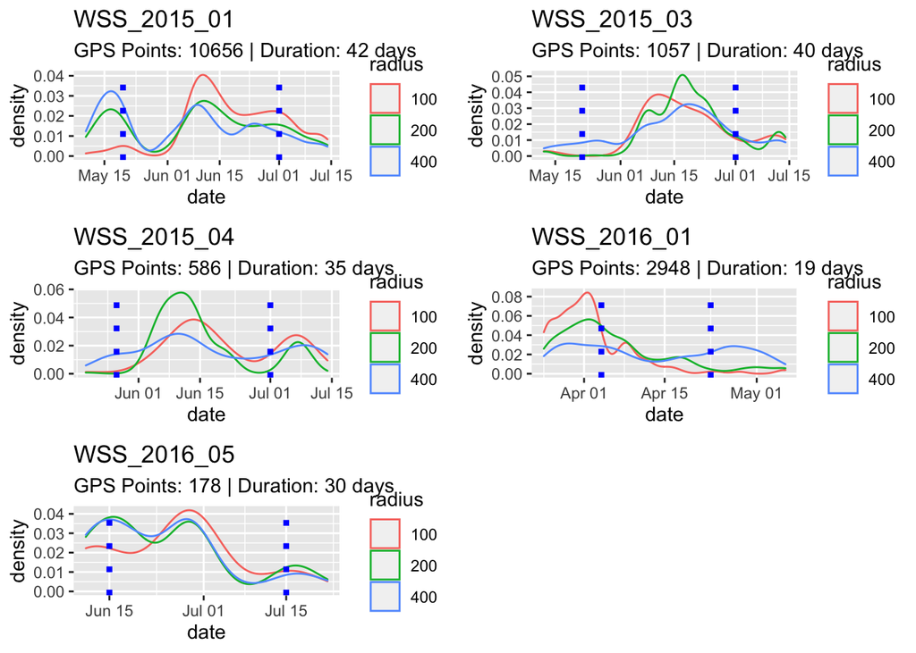

Figure 5: Density plots for each scare off event, 10 days before and 14 days after event

#### Interactive Maps

[interactive chart not shown]

Figure 6: Wild boar location of WSS_2015_01 scare off, 10 days before, during, and 14 days after event. The red dot shows the scare off location, the blue dots are wild boar GPS locations.

[interactive chart not shown]

Figure 7: Wild boar location of WSS_2016_01 scare off, 10 days before, during, and 14 days after event. The red dot shows the scare off location, the blue dots are wild boar GPS locations.

#### Static Maps

##### All Individuals

In addition to the interactive maps, we also generated various static maps that allow us to visualize the spatial distribution of the wild boars in relation to the scare off event and location. *Figure 8* shows the locations of the four individuals, Caroline, Claude, Olga, and Sabine, that were within a 200 m radius of the scare off event WSS_2015_01, 10 days before, during, and 10 days after the event. Caroline and Olga do not seem to be kept away from the scare off, but rather even attracted to it. Also Sabine shows only in the 200 m radius as the scare off is on and remains also afterwards still in the proximity. Only Claude moves away during the scare off event and is no longer within the 200 m radius 10 days after the event.

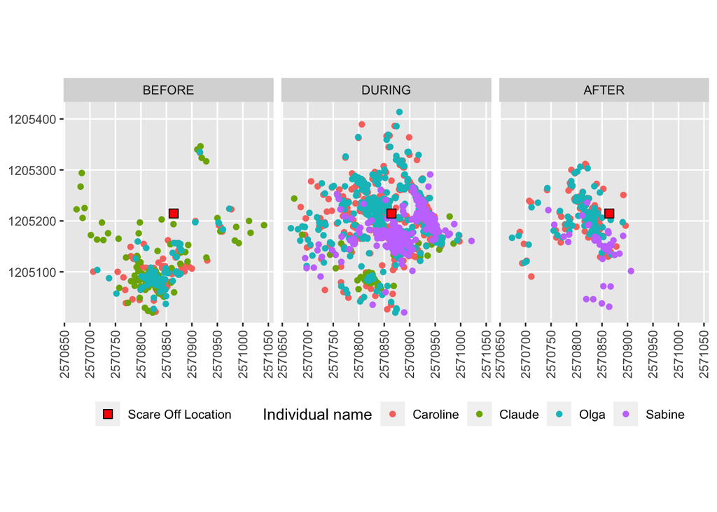

Figure 8: Static map (before, during, after), of WSS_2015_01, radius = 200 m, 10 days before until 10 days after scare off event

At the scare off event/location WSS_2016_01 the individuals Caroline, Frida and Miriam are situated in the observed zone (*Figure 9*). Caroline disappears during the fright event and also Frida moves away from the 200 m radius afterwards. Miriam, however, remains in the vicinity of the scare off location.

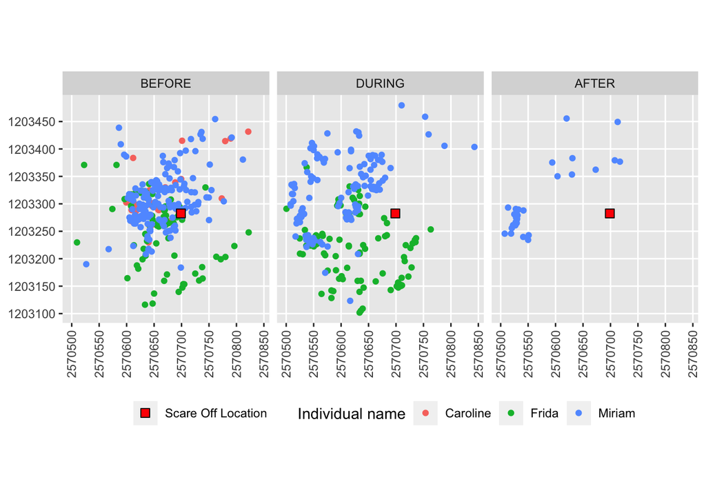

Figure 9: Static map (before, during, after) of WSS_2016_01, radius = 200 m, 10 days before until 10 days after scare off event

##### One Individual

For a more detailed perspective, we wanted to visualize all GPS points of a single individual in relation to a scare off event and location. To decide which individual to focus on, we first selected the scare off location with the highest number of GPS points within its buffer zone over time (see *Figure 5: Density Plots* above). The buffer zone around scare off WSS_2015_01 includes the highest total number of GPS points (10’656).

We then generated a table (*Table 5*) to see how many points belong to each individual within that buffer zone and time period (10 days before until 10 days after the scare off event). We then chose to visualize the movements of the individual with the highest number of points, Sabine.

| TierID | TierName | total |
| --- | --- | --- |
| 2 | Sabine | 5951 |
| 10 | Caroline | 5949 |
| 36 | Olga | 5947 |
| 16 | Rosa | 4882 |
| 40 | Franz | 4806 |
| 18 | Ruth | 4633 |
| 31 | Claude | 1231 |

As a result, we generated *Figure 10*, which shows all of Sabine’s data points from 10 days before until 10 days after the scare off events, outside and inside the buffer zone (r = 200 m, orange) around scare off WSS_2015_01.

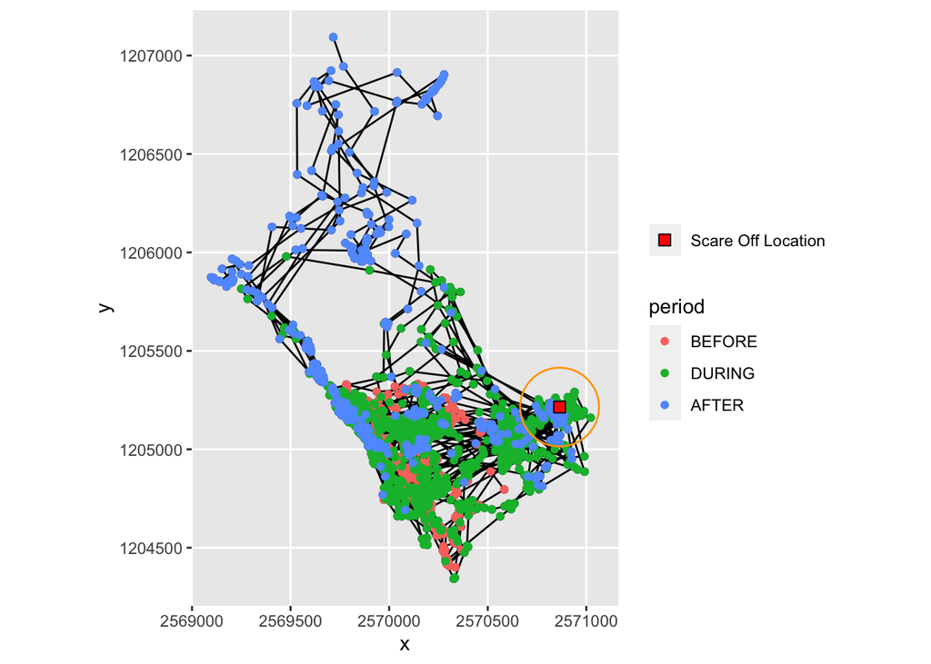

Figure 10: Static map of Sabine’s spatial expansion 10 days before, during, and 10 after scare off event of WSS_2015_01

With regard to the research question posed earlier, how effective the wild boar scare off is in keeping away wild boar, we can already make some statements through the explorative data analysis. Out of the 5 scare offs that were finally selected for consideration, 3 showed the opposite effect of what we expected. Namely, an increase in wild boar occurrence during the scare off period. The scare offs WSS_2016_01 and WSS_2016_05, on the other hand, showed after exploratory analysis, the expected pattern in case of an effective defense measure. For this reason, these two scare offs were examined in more detail in a statistical data analysis.

### Confirmatory Analysis

#### ANOVA and Tukey’s Post-Hoc Boxplot

For WSS_2016_05, no statistically significant effect of the wild boar scare off could be detected, related to the occurrence before, during, and after the event considering an effect radius of 200 m (*Table 7, Figure 12*).

Table 6: Summary of Analysis of Variance Model for scare off WSS_2016_01 (number of GPS locations per day within 200 m radius ~ period in relation to scare off event)

|  | Df | Sum Sq | Mean Sq | F value | Pr(>F) |
| --- | --- | --- | --- | --- | --- |
| **period** | 2 | 1218 | 609 | 9.018 | 0.0001531 |
| **Residuals** | 336 | 22691 | 67.53 | NA | NA |

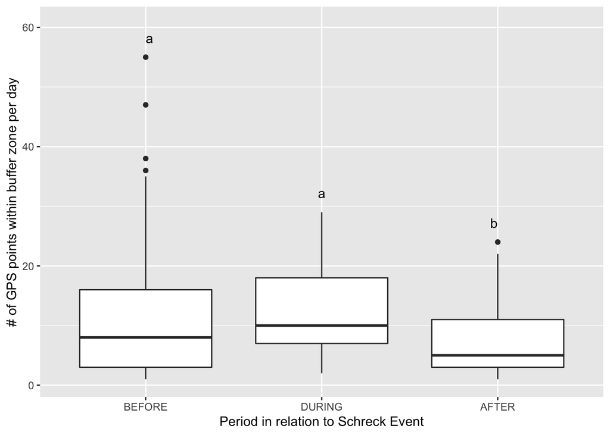

Figure 11: Box Plot with Tukey’s Post-Hoc Test for scare off WSS_2016_01, number of GPS locations per day within 200 m radius, before, during, and after the scare off event

Table 7: Summary of Analysis of Variance Model for scare off WSS_2016_05 (number of GPS locations per day within 200 m radius ~ period in relation to scare off event)

|  | Df | Sum Sq | Mean Sq | F value | Pr(>F) |
| --- | --- | --- | --- | --- | --- |
| **period** | 2 | 19.12 | 9.558 | 0.336 | 0.7163 |
| **Residuals** | 48 | 1366 | 28.45 | NA | NA |

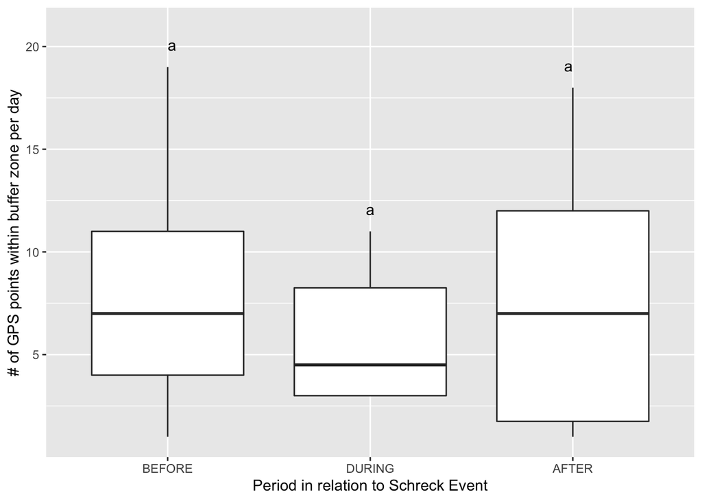

Figure 12: Box Plot with Tukey’s Post-Hoc Test for scare off WSS_2016_05, number of GPS locations per day within 200 m radius, before, during, and after the scare off event

## Scare Off Parameter Settings (Q2)

*Table 8* shows the summary of parameter settings of the relevant scare offs, including the crop on which they were installed. All scare offs were running during a period of low hunting pressure and no fence was placed. Further, the setting of the scare offs phase was 2 for each. As we could not find a significant effect of the scare offs, modelling the impact depending on the settings is not useful. However, a weighing of the density plots (*Figure 5*) based on the settings is possible. WSS_2016_01 and WSS_2016_05 showed both the expected pattern but the parameter settings are different in terms of mode and volume. Taking into consideration the crop species, we assume, that the standard mode in combination with the higher volume was sufficient to defend the meadow and harvesting crops afford tougher defence strategies. Scare offs in 2015 were all installed on wheat (/potato) crops. The mode of WSS_2015_01 and WSS_2015_03 was switched in the mid of June from standard to aggressive and the volume was enhanced as well. That could explain the decrease of the wild boar occurrence in the middle of the scare off events. For WSS_2015_04 no switch of mode was performed, but an increase of volume after the first half of the scare off event, where also a decrease of wild boar occurrence was observed.

Table 8: Parameter settings of relevant scare offs in the Fanel region

| id | flurname | kultur | inst_hoehe | datum_on | datum_off | modus | lautstaerke | intervall | ausrichtung_min | ausrichtung_max |
| --- | --- | --- | --- | --- | --- | --- | --- | --- | --- | --- |
| WSS_2015_01 | tannenhof | weizen | 1.8 | 2015-05-20 | 2015-06-12 | standard v1 | 50 | 15.0 | 140 | 280 |
| WSS_2015_01 | tannenhof | weizen | 1.8 | 2015-06-12 | 2015-07-01 | aggressiv v2 | 75 | 12.5 | 140 | 280 |
| WSS_2015_03 | fanelacher | weizen | 1.8 | 2015-05-22 | 2015-06-12 | standard v1 | 50 | 15.0 | 140 | 320 |
| WSS_2015_03 | fanelacher | weizen | 1.8 | 2015-06-12 | 2015-07-01 | aggressiv v2 | 75 | 15.0 | 140 | 320 |
| WSS_2015_04 | gampelenmoos | weizen&kartoffeln | 2.0 | 2015-05-27 | 2015-06-12 | standard v1 | 50 | 30.0 | 200 | 270 |
| WSS_2015_04 | gampelenmoos | weizen&kartoffeln | 2.0 | 2015-06-12 | 2015-07-01 | standard v1 | 75 | 15.0 | 130 | 310 |
| WSS_2016_01 | reiherwaedli | wiese | 1.7 | 2016-04-04 | 2016-04-23 | standard v3 | 100 | 15.0 | 80 | 180 |
| WSS_2016_05 | vor bruedersgrabe | weizen | 1.8 | 2016-06-15 | 2016-07-15 | aggressiv v3 | 50 | 15.0 | 60 | 240 |

# Discussion

In this work, we set up two research questions that build on each other. To answer them, we first had to filter the data temporally and spatially, taking into account the irregular sampling of wild boar locations on the one hand. On the other hand, the data provided did not include any information on the range of wild boar scare offs, both of which were challenging. We therefore chose to visually estimate the radius studied using exploratory data analysis. For further investigation, a volume in decibels would be helpful to estimate the range considering the hearing ability of wild boars. Furthermore, after filtering and sorting out the scare off events with too short a duration or too few data points, only 5 of the original nearly 70 scare off events remained for consideration. With our goal of having as much useful data as possible, this obviously reduces the statistical power. In the course of this, however, we also found that the scale and resolution of the analysis plays a large role. For example, the behavior of a single wild boar is relatively manageable and easy to interpret, but hardly meaningful for the whole population. On the other hand, pooling all data bears the risk of overlooking individual effects. This is especially true with respect to the scare off events, where we did not initially consider the crop and parameter settings.

To answer the first research question, we compared the scare off periods, showing very different data volumes per scare off event. This in turn affects the statistical comparability in the second step. The 10 day pre- and post-scare off periods tend to represent the immediate impact of the scare offs, and lengthening or restricting these periods may lead to different results. In summary, although there was a visual effect of the scare offs, it was not statistically significant. Thus, based on our data and analysis, we cannot answer the second part of the research question, how long the effect of the scare offs lasts.

Since no significant effect of the scare off could be detected, we did not consider it useful to generate a statistical model to describe the ability of the wild boars to stay away. Therefore, only statements based on exploratory data analysis are possible. Nevertheless, differences in the importance of individual parameters can be seen when comparing the parameter settings, in regard of research question 2. For example, the mode and the volume seem to have an effect on the efficiency. This is especially indicated by the decrease in the occurrence of wild boar after switching the mode from standard to aggressive and increasing the volume. In the first part of the data analysis, we did not consider switching of the mode. In retrospect, it appears to have had an effect. However, our analysis strategy requires a certain amount of time before and after the scare off event to have a basis for comparison as a control, which is not the case with switching mode without interruption. Also, the comparison with a previous year based on these data was not possible, because the wild boars were tracked in irregular intervals. Furthermore, other effects, such as different crops and weather conditions or random behavior of the wild boars could dominate here.

In conclusion, although our data analysis did not show a significant effect of the scare offs, we were able to show that the scaling influences the results. In a further analysis, it would therefore be useful to distinguish between crops and parameters at the beginning. Furthermore, a better alignment of the data collection of wild boar locations and scare off events is advisable in a re-sampling to be able to use the data efficiently.

# References

1. Suter Forschungsgruppe Wildtiermanagement WILMA, S. Forschungsprojekt Prävention von Wildschweinschäden in Der Landwirtschaft, 2013.
2. Thurfjell, H.; Ball, J. P.; Åhlén, P.-A.; Kornacher, P.; Dettki, H.; Sjöberg, K. Habitat Use and Spatial Patterns of Wild Boar Sus Scrofa (L.): Agricultural Fields and Edges. European Journal of Wildlife Research 2009, 55 (5), 517–523. https://doi.org/10.1007/s10344-009-0268-1.
3. Geisser, H.; Reyer, H. The Influence of Food and Temperature on Population Density of Wild Boar (Sus Scrofa) in the Thurgau (Switzerland). Journal of Zoology 2005, 267 (1), 89–96. https://doi.org/10.1017/S095283690500734X.
4. Geisser, H. Efficacy of Hunting, Feeding, and Fencing to Reduce Crop Damage by Wild Boars. https://doi.org/10.2193/0022-541X.
5. Jagdstatistik. https://www.jagdstatistik.ch/de/statistics?tt=2&dt=0&at=0&st=0&dp=0&ar=GE&th=1&yr%5Bfrom%5D=2000&yr%5Bto%5D=2020&sp=350 (accessed 2022-06-22).
6. Wildschweinmanagement – Lernen aus der Erfahrung anderer. https://www.admin.ch/gov/de/start/dokumentation/medienmitteilungen.msg-id-8817.html (accessed 2022-06-22).
7. Thurfjell, H.; Spong, G.; Ericsson, G. Effects of Hunting on Wild Boar (Sus Scrofa) Behaviour. Wildlife Biology 2013, 19 (1), 87–93. https://doi.org/10.2981/12-027.
8. Meynhardt H. Untersuchung Zur Akustischen, Olfaktorischen Und Visuellen Kommunikation Des Europäischen Wildschweines (Sus Scarofa L.). Beiträge für die Frorstwirtschaft 1980, 14 (2), 74–82.
9. Laube, P. Representation: Trajectories. In International Encyclopedia of Geography: People, the Earth, Environment and Technology; John Wiley & Sons, Ltd: Oxford, UK, 2017; pp 1–11. https://doi.org/10.1002/9781118786352.wbieg0593.
10. Laube, P. Computational Movement Analysis; Springer International Publishing: Cham, 2014. https://doi.org/10.1007/978-3-319-10268-9.